# SSBU: Data Science Tier List

Clurkastas

6 10 2019

# 1 Data Gathering

To gather information for my tier list, I used the RPackage “RSelenium”. It gathered 490 video titles from [this Youtube link](https://www.youtube.com/results?search_query=ssbu+grand+finals&sp=CAI%253D). The link was created by searching for “SSBU grand finals” ordered by date.

After that I had to clean out the data. For this I searched for all fighter names inside the video titles. It was important to e.g. first search for “Dr. Mario”, deleting this part of the string, and then search for “Mario”, because otherwise the data would not have been correct. Additionally, I needed to search for multiple variants of a name, e.g. “ZSS” and “Zero Suit Samus” or “Olimar” and “Alph”.

# 2 Analysis

Eventually, I got a sum of observations for each character in SSBU. I added the tier list information from [ZeRo’s tier list](https://smash-tier-list.com/ultimate) to compare my results to external information. From all the information gathered I created some interesting charts:

## 2.1 Chart with ZeRo’s Tier list and amount of mentioning in grand final videos

[figure not shown]

The correlation here is 0.46

## 2.2 Same chart but log10(amount)

[figure not shown]

The correlation here is 0.44

## 2.3 Data Science Tier List (compared with ZeRo’s) graphics

Bases on the amounts of mentioning I made some tier groups myself. For this I just had to decide on the cut-off values between the tier list levels.

[figure not shown]

[figure not shown]

[figure not shown]

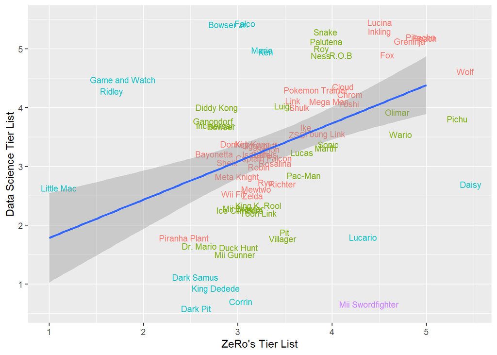

# 3 The Data Science Tier List

[output not shown]